# Risk Factor Analysis

## Outcome Variable

**Outcome Variable:** y_rate_haz

## Predictor Variables

**Intervention Variable:** nhh

**Adjustment Set:**

- arm
- W_mage
- meducyrs
- feducyrs
- W_mhtcm
- W_mwtkg
- W_mbmi
- W_nrooms
- trth2o
- cleanck
- impfloor
- impsan
- safeh20
- delta_W_mage
- delta_meducyrs
- delta_feducyrs
- delta_W_mhtcm
- delta_W_mwtkg
- delta_W_mbmi
- delta_W_nrooms
- delta_trth2o
- delta_cleanck
- delta_impfloor
- delta_impsan
- delta_safeh20

## Stratifying Variables

The analysis was stratified on these variable(s):

- agecat
- studyid
- country

## Data Summary

| agecat | studyid | country | nhh | n_cell | n |
| --- | --- | --- | --- | --- | --- |
| 0-3 months | IRC | INDIA | 3 or less | 53 | 377 |
| 0-3 months | IRC | INDIA | 4-5 | 146 | 377 |
| 0-3 months | IRC | INDIA | 6-7 | 99 | 377 |
| 0-3 months | IRC | INDIA | 8+ | 79 | 377 |
| 0-3 months | NIH-Birth | BANGLADESH | 3 or less | 101 | 566 |
| 0-3 months | NIH-Birth | BANGLADESH | 4-5 | 239 | 566 |
| 0-3 months | NIH-Birth | BANGLADESH | 6-7 | 132 | 566 |
| 0-3 months | NIH-Birth | BANGLADESH | 8+ | 94 | 566 |
| 0-3 months | NIH-Crypto | BANGLADESH | 3 or less | 108 | 721 |
| 0-3 months | NIH-Crypto | BANGLADESH | 4-5 | 324 | 721 |
| 0-3 months | NIH-Crypto | BANGLADESH | 6-7 | 169 | 721 |
| 0-3 months | NIH-Crypto | BANGLADESH | 8+ | 120 | 721 |
| 0-3 months | PROVIDE | BANGLADESH | 3 or less | 123 | 640 |
| 0-3 months | PROVIDE | BANGLADESH | 4-5 | 296 | 640 |
| 0-3 months | PROVIDE | BANGLADESH | 6-7 | 136 | 640 |
| 0-3 months | PROVIDE | BANGLADESH | 8+ | 85 | 640 |
| 3-6 months | IRC | INDIA | 3 or less | 57 | 397 |
| 3-6 months | IRC | INDIA | 4-5 | 154 | 397 |
| 3-6 months | IRC | INDIA | 6-7 | 103 | 397 |
| 3-6 months | IRC | INDIA | 8+ | 83 | 397 |
| 3-6 months | NIH-Birth | BANGLADESH | 3 or less | 89 | 523 |
| 3-6 months | NIH-Birth | BANGLADESH | 4-5 | 223 | 523 |
| 3-6 months | NIH-Birth | BANGLADESH | 6-7 | 126 | 523 |
| 3-6 months | NIH-Birth | BANGLADESH | 8+ | 85 | 523 |
| 3-6 months | NIH-Crypto | BANGLADESH | 3 or less | 101 | 695 |
| 3-6 months | NIH-Crypto | BANGLADESH | 4-5 | 316 | 695 |
| 3-6 months | NIH-Crypto | BANGLADESH | 6-7 | 163 | 695 |
| 3-6 months | NIH-Crypto | BANGLADESH | 8+ | 115 | 695 |
| 3-6 months | PROVIDE | BANGLADESH | 3 or less | 104 | 598 |
| 3-6 months | PROVIDE | BANGLADESH | 4-5 | 285 | 598 |

[output cut: 138 more lines]

The following strata were considered:

- agecat: 0-3 months, studyid: IRC, country: INDIA
- agecat: 0-3 months, studyid: NIH-Birth, country: BANGLADESH
- agecat: 0-3 months, studyid: NIH-Crypto, country: BANGLADESH
- agecat: 0-3 months, studyid: PROVIDE, country: BANGLADESH
- agecat: 12-15 months, studyid: IRC, country: INDIA
- agecat: 12-15 months, studyid: LCNI-5, country: MALAWI
- agecat: 12-15 months, studyid: NIH-Birth, country: BANGLADESH
- agecat: 12-15 months, studyid: NIH-Crypto, country: BANGLADESH
- agecat: 12-15 months, studyid: PROVIDE, country: BANGLADESH
- agecat: 12-15 months, studyid: SAS-FoodSuppl, country: INDIA
- agecat: 15-18 months, studyid: IRC, country: INDIA
- agecat: 15-18 months, studyid: LCNI-5, country: MALAWI
- agecat: 15-18 months, studyid: NIH-Birth, country: BANGLADESH
- agecat: 15-18 months, studyid: NIH-Crypto, country: BANGLADESH
- agecat: 15-18 months, studyid: PROVIDE, country: BANGLADESH
- agecat: 15-18 months, studyid: SAS-FoodSuppl, country: INDIA
- agecat: 18-21 months, studyid: IRC, country: INDIA
- agecat: 18-21 months, studyid: LCNI-5, country: MALAWI
- agecat: 18-21 months, studyid: NIH-Birth, country: BANGLADESH
- agecat: 18-21 months, studyid: NIH-Crypto, country: BANGLADESH
- agecat: 18-21 months, studyid: PROVIDE, country: BANGLADESH
- agecat: 21-24 months, studyid: IRC, country: INDIA
- agecat: 21-24 months, studyid: LCNI-5, country: MALAWI
- agecat: 21-24 months, studyid: NIH-Birth, country: BANGLADESH
- agecat: 21-24 months, studyid: NIH-Crypto, country: BANGLADESH
- agecat: 21-24 months, studyid: PROVIDE, country: BANGLADESH
- agecat: 3-6 months, studyid: IRC, country: INDIA
- agecat: 3-6 months, studyid: NIH-Birth, country: BANGLADESH
- agecat: 3-6 months, studyid: NIH-Crypto, country: BANGLADESH
- agecat: 3-6 months, studyid: PROVIDE, country: BANGLADESH
- agecat: 6-9 months, studyid: IRC, country: INDIA
- agecat: 6-9 months, studyid: LCNI-5, country: MALAWI
- agecat: 6-9 months, studyid: NIH-Birth, country: BANGLADESH
- agecat: 6-9 months, studyid: NIH-Crypto, country: BANGLADESH
- agecat: 6-9 months, studyid: PROVIDE, country: BANGLADESH
- agecat: 6-9 months, studyid: SAS-FoodSuppl, country: INDIA
- agecat: 9-12 months, studyid: IRC, country: INDIA
- agecat: 9-12 months, studyid: LCNI-5, country: MALAWI
- agecat: 9-12 months, studyid: NIH-Birth, country: BANGLADESH
- agecat: 9-12 months, studyid: NIH-Crypto, country: BANGLADESH
- agecat: 9-12 months, studyid: PROVIDE, country: BANGLADESH
- agecat: 9-12 months, studyid: SAS-FoodSuppl, country: INDIA

## Methods Detail

We’re interested in the causal parameters $E[Y_a]$ for all values of $a \in \mathcal{A}$. These parameters represent the mean outcome if, possibly contrary to fact, we intervened to set all units to have $A=a$. Under the randomization and positivity assumptions, these are identified by the statistical parameters $\psi_a=E_W[E_{Y|A,W}(Y|A=a,W)]$. In addition, we’re interested in the mean of $Y$, $E[Y]$ under no intervention (the observed mean). We will estimate these parameters by using SuperLearner to fit the relevant likelihood factors – $E_{Y|A,W}(Y|A=a,W)$ and $p(A=a|W)$, and then updating our likelihood fit using a joint TMLE.

For unadjusted analyses ($W=\{\}$), initial likelihoods were estimated using Lrnr_glm to estimate the simple $E(Y|A)$ and Lrnr_mean to estimate $p(A)$. For adjusted analyses, a small library containing Lrnr_glmnet, Lrnr_xgboost, and Lrnr_mean was used.

Having estimated these parameters, we will then use the delta method to estimate relative risks and attributable risks relative to a prespecified baseline level of $A$.

# Results Detail

## Results Plots

[figure not shown]

[figure not shown]

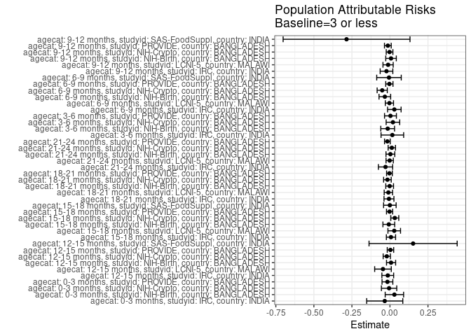

## Results Table

### Parameter: TSM

| agecat | studyid | country | intervention_level | baseline_level | estimate | ci_lower | ci_upper |
| --- | --- | --- | --- | --- | --- | --- | --- |
| 0-3 months | IRC | INDIA | 3 or less | NA | -0.2215656 | -0.3484731 | -0.0946581 |
| 0-3 months | IRC | INDIA | 4-5 | NA | -0.2682499 | -0.3556386 | -0.1808612 |
| 0-3 months | IRC | INDIA | 6-7 | NA | -0.1820348 | -0.3120854 | -0.0519842 |
| 0-3 months | IRC | INDIA | 8+ | NA | -0.3130853 | -0.4249579 | -0.2012128 |
| 0-3 months | NIH-Birth | BANGLADESH | 3 or less | NA | -0.2612160 | -0.3273719 | -0.1950601 |
| 0-3 months | NIH-Birth | BANGLADESH | 4-5 | NA | -0.2454018 | -0.2839789 | -0.2068247 |
| 0-3 months | NIH-Birth | BANGLADESH | 6-7 | NA | -0.2262768 | -0.2958987 | -0.1566549 |
| 0-3 months | NIH-Birth | BANGLADESH | 8+ | NA | -0.1909296 | -0.2627229 | -0.1191364 |
| 0-3 months | NIH-Crypto | BANGLADESH | 3 or less | NA | -0.2255202 | -0.2786873 | -0.1723531 |
| 0-3 months | NIH-Crypto | BANGLADESH | 4-5 | NA | -0.2364402 | -0.2669735 | -0.2059068 |
| 0-3 months | NIH-Crypto | BANGLADESH | 6-7 | NA | -0.2135249 | -0.2654429 | -0.1616070 |
| 0-3 months | NIH-Crypto | BANGLADESH | 8+ | NA | -0.1790183 | -0.2180997 | -0.1399369 |
| 0-3 months | PROVIDE | BANGLADESH | 3 or less | NA | -0.1714546 | -0.2103367 | -0.1325725 |
| 0-3 months | PROVIDE | BANGLADESH | 4-5 | NA | -0.1839649 | -0.2108544 | -0.1570755 |
| 0-3 months | PROVIDE | BANGLADESH | 6-7 | NA | -0.1957378 | -0.2379435 | -0.1535322 |
| 0-3 months | PROVIDE | BANGLADESH | 8+ | NA | -0.2100175 | -0.2592735 | -0.1607614 |
| 3-6 months | IRC | INDIA | 3 or less | NA | -0.0676702 | -0.1479394 | 0.0125990 |
| 3-6 months | IRC | INDIA | 4-5 | NA | -0.0556459 | -0.1064976 | -0.0047942 |
| 3-6 months | IRC | INDIA | 6-7 | NA | -0.0684867 | -0.1208473 | -0.0161261 |
| 3-6 months | IRC | INDIA | 8+ | NA | -0.0069836 | -0.0795312 | 0.0655641 |
| 3-6 months | NIH-Birth | BANGLADESH | 3 or less | NA | -0.0359534 | -0.0830748 | 0.0111679 |
| 3-6 months | NIH-Birth | BANGLADESH | 4-5 | NA | -0.0821378 | -0.1182817 | -0.0459939 |
| 3-6 months | NIH-Birth | BANGLADESH | 6-7 | NA | -0.0144172 | -0.0674124 | 0.0385781 |
| 3-6 months | NIH-Birth | BANGLADESH | 8+ | NA | -0.0356627 | -0.0920083 | 0.0206828 |
| 3-6 months | NIH-Crypto | BANGLADESH | 3 or less | NA | 0.0071928 | -0.0383412 | 0.0527268 |
| 3-6 months | NIH-Crypto | BANGLADESH | 4-5 | NA | 0.0304821 | 0.0028285 | 0.0581357 |
| 3-6 months | NIH-Crypto | BANGLADESH | 6-7 | NA | 0.0263063 | -0.0219163 | 0.0745289 |
| 3-6 months | NIH-Crypto | BANGLADESH | 8+ | NA | -0.0478284 | -0.0933621 | -0.0022947 |
| 3-6 months | PROVIDE | BANGLADESH | 3 or less | NA | -0.0303683 | -0.0735002 | 0.0127635 |
| 3-6 months | PROVIDE | BANGLADESH | 4-5 | NA | -0.0352676 | -0.0572150 | -0.0133203 |

[output cut: 138 more lines]

### Parameter: E(Y)

| agecat | studyid | country | intervention_level | baseline_level | estimate | ci_lower | ci_upper |
| --- | --- | --- | --- | --- | --- | --- | --- |
| 0-3 months | IRC | INDIA | NA | NA | -0.2558271 | -0.3111464 | -0.2005078 |
| 0-3 months | NIH-Birth | BANGLADESH | NA | NA | -0.2319865 | -0.2585900 | -0.2053830 |
| 0-3 months | NIH-Crypto | BANGLADESH | NA | NA | -0.2312607 | -0.2486732 | -0.2138483 |
| 0-3 months | PROVIDE | BANGLADESH | NA | NA | -0.1880402 | -0.2054115 | -0.1706689 |
| 3-6 months | IRC | INDIA | NA | NA | -0.0518918 | -0.0819849 | -0.0217987 |
| 3-6 months | NIH-Birth | BANGLADESH | NA | NA | -0.0509007 | -0.0730097 | -0.0287917 |
| 3-6 months | NIH-Crypto | BANGLADESH | NA | NA | 0.0267740 | 0.0099602 | 0.0435879 |
| 3-6 months | PROVIDE | BANGLADESH | NA | NA | -0.0269625 | -0.0428628 | -0.0110622 |
| 6-9 months | IRC | INDIA | NA | NA | -0.0162677 | -0.0378604 | 0.0053250 |
| 6-9 months | LCNI-5 | MALAWI | NA | NA | 0.0279334 | 0.0120046 | 0.0438622 |
| 6-9 months | NIH-Birth | BANGLADESH | NA | NA | -0.0595548 | -0.0774135 | -0.0416961 |
| 6-9 months | NIH-Crypto | BANGLADESH | NA | NA | -0.0313638 | -0.0441155 | -0.0186120 |
| 6-9 months | PROVIDE | BANGLADESH | NA | NA | -0.0614264 | -0.0722690 | -0.0505838 |
| 6-9 months | SAS-FoodSuppl | INDIA | NA | NA | -0.1052304 | -0.1233192 | -0.0871417 |
| 9-12 months | IRC | INDIA | NA | NA | -0.0361313 | -0.0530672 | -0.0191954 |
| 9-12 months | LCNI-5 | MALAWI | NA | NA | -0.0433141 | -0.0626948 | -0.0239333 |
| 9-12 months | NIH-Birth | BANGLADESH | NA | NA | -0.0424748 | -0.0569242 | -0.0280255 |
| 9-12 months | NIH-Crypto | BANGLADESH | NA | NA | -0.0342995 | -0.0452397 | -0.0233593 |
| 9-12 months | PROVIDE | BANGLADESH | NA | NA | -0.0630470 | -0.0740183 | -0.0520757 |
| 9-12 months | SAS-FoodSuppl | INDIA | NA | NA | -0.1462637 | -0.2015231 | -0.0910043 |
| 12-15 months | IRC | INDIA | NA | NA | -0.0454519 | -0.0622041 | -0.0286997 |
| 12-15 months | LCNI-5 | MALAWI | NA | NA | -0.0403575 | -0.0774359 | -0.0032790 |
| 12-15 months | NIH-Birth | BANGLADESH | NA | NA | -0.1259588 | -0.1428870 | -0.1090306 |
| 12-15 months | NIH-Crypto | BANGLADESH | NA | NA | -0.0383313 | -0.0478154 | -0.0288473 |
| 12-15 months | PROVIDE | BANGLADESH | NA | NA | -0.0409107 | -0.0510053 | -0.0308161 |
| 12-15 months | SAS-FoodSuppl | INDIA | NA | NA | 0.0088746 | -0.0268397 | 0.0445889 |
| 15-18 months | IRC | INDIA | NA | NA | -0.0385167 | -0.0531981 | -0.0238352 |
| 15-18 months | LCNI-5 | MALAWI | NA | NA | -0.0464023 | -0.0722064 | -0.0205982 |
| 15-18 months | NIH-Birth | BANGLADESH | NA | NA | -0.0576906 | -0.0723785 | -0.0430027 |
| 15-18 months | NIH-Crypto | BANGLADESH | NA | NA | -0.0169074 | -0.0252557 | -0.0085590 |
| 15-18 months | PROVIDE | BANGLADESH | NA | NA | -0.0376437 | -0.0463882 | -0.0288992 |
| 15-18 months | SAS-FoodSuppl | INDIA | NA | NA | -0.0369125 | -0.0500204 | -0.0238046 |
| 18-21 months | IRC | INDIA | NA | NA | -0.0400816 | -0.0533440 | -0.0268193 |
| 18-21 months | LCNI-5 | MALAWI | NA | NA | -0.0147327 | -0.0309734 | 0.0015080 |
| 18-21 months | NIH-Birth | BANGLADESH | NA | NA | -0.0383890 | -0.0508204 | -0.0259576 |
| 18-21 months | NIH-Crypto | BANGLADESH | NA | NA | -0.0279687 | -0.0360019 | -0.0199355 |
| 18-21 months | PROVIDE | BANGLADESH | NA | NA | -0.0109399 | -0.0190984 | -0.0027814 |
| 21-24 months | IRC | INDIA | NA | NA | -0.0139081 | -0.0274784 | -0.0003379 |
| 21-24 months | LCNI-5 | MALAWI | NA | NA | 0.0258428 | 0.0105053 | 0.0411803 |
| 21-24 months | NIH-Birth | BANGLADESH | NA | NA | 0.0406915 | 0.0289394 | 0.0524435 |
| 21-24 months | NIH-Crypto | BANGLADESH | NA | NA | 0.0587621 | 0.0505315 | 0.0669927 |
| 21-24 months | PROVIDE | BANGLADESH | NA | NA | 0.0462342 | 0.0375872 | 0.0548812 |

### Parameter: ATE

| agecat | studyid | country | intervention_level | baseline_level | estimate | ci_lower | ci_upper |
| --- | --- | --- | --- | --- | --- | --- | --- |
| 0-3 months | IRC | INDIA | 3 or less | 3 or less | 0.0000000 | 0.0000000 | 0.0000000 |
| 0-3 months | IRC | INDIA | 4-5 | 3 or less | -0.0466843 | -0.2005743 | 0.1072058 |
| 0-3 months | IRC | INDIA | 6-7 | 3 or less | 0.0395308 | -0.1418807 | 0.2209424 |
| 0-3 months | IRC | INDIA | 8+ | 3 or less | -0.0915197 | -0.2606405 | 0.0776011 |
| 0-3 months | NIH-Birth | BANGLADESH | 3 or less | 3 or less | 0.0000000 | 0.0000000 | 0.0000000 |
| 0-3 months | NIH-Birth | BANGLADESH | 4-5 | 3 or less | 0.0158142 | -0.0609833 | 0.0926117 |
| 0-3 months | NIH-Birth | BANGLADESH | 6-7 | 3 or less | 0.0349392 | -0.0610639 | 0.1309423 |
| 0-3 months | NIH-Birth | BANGLADESH | 8+ | 3 or less | 0.0702864 | -0.0276936 | 0.1682664 |
| 0-3 months | NIH-Crypto | BANGLADESH | 3 or less | 3 or less | 0.0000000 | 0.0000000 | 0.0000000 |
| 0-3 months | NIH-Crypto | BANGLADESH | 4-5 | 3 or less | -0.0109200 | -0.0723563 | 0.0505163 |
| 0-3 months | NIH-Crypto | BANGLADESH | 6-7 | 3 or less | 0.0119953 | -0.0625783 | 0.0865688 |
| 0-3 months | NIH-Crypto | BANGLADESH | 8+ | 3 or less | 0.0465019 | -0.0196960 | 0.1126998 |
| 0-3 months | PROVIDE | BANGLADESH | 3 or less | 3 or less | 0.0000000 | 0.0000000 | 0.0000000 |
| 0-3 months | PROVIDE | BANGLADESH | 4-5 | 3 or less | -0.0125103 | -0.0598992 | 0.0348785 |
| 0-3 months | PROVIDE | BANGLADESH | 6-7 | 3 or less | -0.0242832 | -0.0816329 | 0.0330665 |
| 0-3 months | PROVIDE | BANGLADESH | 8+ | 3 or less | -0.0385629 | -0.1012534 | 0.0241277 |
| 3-6 months | IRC | INDIA | 3 or less | 3 or less | 0.0000000 | 0.0000000 | 0.0000000 |
| 3-6 months | IRC | INDIA | 4-5 | 3 or less | 0.0120243 | -0.0831409 | 0.1071895 |
| 3-6 months | IRC | INDIA | 6-7 | 3 or less | -0.0008165 | -0.0968397 | 0.0952067 |
| 3-6 months | IRC | INDIA | 8+ | 3 or less | 0.0606866 | -0.0476904 | 0.1690637 |
| 3-6 months | NIH-Birth | BANGLADESH | 3 or less | 3 or less | 0.0000000 | 0.0000000 | 0.0000000 |
| 3-6 months | NIH-Birth | BANGLADESH | 4-5 | 3 or less | -0.0461843 | -0.1060501 | 0.0136815 |
| 3-6 months | NIH-Birth | BANGLADESH | 6-7 | 3 or less | 0.0215363 | -0.0497603 | 0.0928329 |
| 3-6 months | NIH-Birth | BANGLADESH | 8+ | 3 or less | 0.0002907 | -0.0733846 | 0.0739660 |
| 3-6 months | NIH-Crypto | BANGLADESH | 3 or less | 3 or less | 0.0000000 | 0.0000000 | 0.0000000 |
| 3-6 months | NIH-Crypto | BANGLADESH | 4-5 | 3 or less | 0.0232893 | -0.0300940 | 0.0766725 |
| 3-6 months | NIH-Crypto | BANGLADESH | 6-7 | 3 or less | 0.0191135 | -0.0472368 | 0.0854638 |
| 3-6 months | NIH-Crypto | BANGLADESH | 8+ | 3 or less | -0.0550212 | -0.1195129 | 0.0094705 |
| 3-6 months | PROVIDE | BANGLADESH | 3 or less | 3 or less | 0.0000000 | 0.0000000 | 0.0000000 |
| 3-6 months | PROVIDE | BANGLADESH | 4-5 | 3 or less | -0.0048993 | -0.0533215 | 0.0435229 |

[output cut: 138 more lines]

### Parameter: PAR

| agecat | studyid | country | intervention_level | baseline_level | estimate | ci_lower | ci_upper |
| --- | --- | --- | --- | --- | --- | --- | --- |
| 0-3 months | IRC | INDIA | 3 or less | NA | -0.0342615 | -0.1529259 | 0.0844030 |
| 0-3 months | NIH-Birth | BANGLADESH | 3 or less | NA | 0.0292295 | -0.0313289 | 0.0897879 |
| 0-3 months | NIH-Crypto | BANGLADESH | 3 or less | NA | -0.0057406 | -0.0561704 | 0.0446893 |
| 0-3 months | PROVIDE | BANGLADESH | 3 or less | NA | -0.0165856 | -0.0520721 | 0.0189009 |
| 3-6 months | IRC | INDIA | 3 or less | NA | 0.0157784 | -0.0585639 | 0.0901207 |
| 3-6 months | NIH-Birth | BANGLADESH | 3 or less | NA | -0.0149473 | -0.0601248 | 0.0302303 |
| 3-6 months | NIH-Crypto | BANGLADESH | 3 or less | NA | 0.0195812 | -0.0250087 | 0.0641712 |
| 3-6 months | PROVIDE | BANGLADESH | 3 or less | NA | 0.0034058 | -0.0356236 | 0.0424353 |
| 6-9 months | IRC | INDIA | 3 or less | NA | 0.0288944 | -0.0154574 | 0.0732462 |
| 6-9 months | LCNI-5 | MALAWI | 3 or less | NA | -0.0035966 | -0.0305241 | 0.0233310 |
| 6-9 months | NIH-Birth | BANGLADESH | 3 or less | NA | -0.0335665 | -0.0718221 | 0.0046892 |
| 6-9 months | NIH-Crypto | BANGLADESH | 3 or less | NA | -0.0508189 | -0.0842176 | -0.0174202 |
| 6-9 months | PROVIDE | BANGLADESH | 3 or less | NA | -0.0038425 | -0.0275927 | 0.0199077 |
| 6-9 months | SAS-FoodSuppl | INDIA | 3 or less | NA | -0.0063617 | -0.0870213 | 0.0742979 |
| 9-12 months | IRC | INDIA | 3 or less | NA | -0.0227082 | -0.0642981 | 0.0188817 |
| 9-12 months | LCNI-5 | MALAWI | 3 or less | NA | -0.0122702 | -0.0459097 | 0.0213694 |
| 9-12 months | NIH-Birth | BANGLADESH | 3 or less | NA | 0.0071277 | -0.0275255 | 0.0417809 |
| 9-12 months | NIH-Crypto | BANGLADESH | 3 or less | NA | -0.0025928 | -0.0244850 | 0.0192995 |
| 9-12 months | PROVIDE | BANGLADESH | 3 or less | NA | -0.0137651 | -0.0359620 | 0.0084318 |
| 9-12 months | SAS-FoodSuppl | INDIA | 3 or less | NA | -0.2851723 | -0.7021747 | 0.1318300 |
| 12-15 months | IRC | INDIA | 3 or less | NA | -0.0143817 | -0.0530639 | 0.0243005 |
| 12-15 months | LCNI-5 | MALAWI | 3 or less | NA | -0.0458204 | -0.1005289 | 0.0088882 |
| 12-15 months | NIH-Birth | BANGLADESH | 3 or less | NA | 0.0073485 | -0.0226373 | 0.0373344 |
| 12-15 months | NIH-Crypto | BANGLADESH | 3 or less | NA | -0.0207900 | -0.0446551 | 0.0030751 |
| 12-15 months | PROVIDE | BANGLADESH | 3 or less | NA | 0.0033671 | -0.0177447 | 0.0244788 |
| 12-15 months | SAS-FoodSuppl | INDIA | 3 or less | NA | 0.1522094 | -0.1374789 | 0.4418976 |
| 15-18 months | IRC | INDIA | 3 or less | NA | 0.0067346 | -0.0235647 | 0.0370339 |
| 15-18 months | LCNI-5 | MALAWI | 3 or less | NA | 0.0281119 | -0.0132476 | 0.0694715 |
| 15-18 months | NIH-Birth | BANGLADESH | 3 or less | NA | -0.0074603 | -0.0462057 | 0.0312851 |
| 15-18 months | NIH-Crypto | BANGLADESH | 3 or less | NA | 0.0318222 | 0.0055909 | 0.0580535 |
| 15-18 months | PROVIDE | BANGLADESH | 3 or less | NA | -0.0023607 | -0.0227468 | 0.0180254 |
| 15-18 months | SAS-FoodSuppl | INDIA | 3 or less | NA | -0.0006019 | -0.0418465 | 0.0406426 |
| 18-21 months | IRC | INDIA | 3 or less | NA | -0.0064549 | -0.0390892 | 0.0261794 |
| 18-21 months | LCNI-5 | MALAWI | 3 or less | NA | -0.0103248 | -0.0379131 | 0.0172634 |
| 18-21 months | NIH-Birth | BANGLADESH | 3 or less | NA | -0.0019613 | -0.0273282 | 0.0234055 |
| 18-21 months | NIH-Crypto | BANGLADESH | 3 or less | NA | -0.0165912 | -0.0416462 | 0.0084638 |
| 18-21 months | PROVIDE | BANGLADESH | 3 or less | NA | -0.0032928 | -0.0221372 | 0.0155517 |
| 21-24 months | IRC | INDIA | 3 or less | NA | -0.0291403 | -0.0759331 | 0.0176525 |
| 21-24 months | LCNI-5 | MALAWI | 3 or less | NA | -0.0017995 | -0.0257284 | 0.0221293 |
| 21-24 months | NIH-Birth | BANGLADESH | 3 or less | NA | 0.0029319 | -0.0260386 | 0.0319023 |
| 21-24 months | NIH-Crypto | BANGLADESH | 3 or less | NA | 0.0122992 | -0.0118279 | 0.0364264 |
| 21-24 months | PROVIDE | BANGLADESH | 3 or less | NA | -0.0168690 | -0.0355309 | 0.0017928 |